# project(dbscan)

```python
# Basic Libraries
import numpy as np
import pandas as pd
import seaborn as sb
import matplotlib.pyplot as plt # we only need pyplot
sb.set() # set the default Seaborn style for graphics

from sklearn.preprocessing import OneHotEncoder, StandardScaler, MultiLabelBinarizer
import seaborn as sb
import polars as pl
import matplotlib.pyplot as plt
# import seaborn.objects as so
# from seaborn.objects import Plot

from sklearn.preprocessing import StandardScaler, MultiLabelBinarizer
from kmodes.kprototypes import KPrototypes

import logging

# from usg.utils import *

log = logging.getLogger(__name__)
log.setLevel(logging.INFO)
sb.set()
```

```python
# pip install seaborn
```

DATA cleaning Exploraratory analysis Data visualisation sDbs scan silhoutee , elbow, clustering

```python
# pip install polars
```

merging datasets filtering the review scores based on order status to delivered reclassifying review scores splitting datasets removing duplicate and null values balance review

# 1 Remove duplicate or irrelevant observations

# 2 Fix structural errors

# 3 Filter unwanted outliers

# 4 Handle missing data

# Importing dataset

```python
#a=steam
a=pd.read_csv("C:\\Users\\Nancy\\OneDrive\\Documents\\sem2\\sc1015\\project\\archive\\steam.csv")
#b=steam description data
b=pd.read_csv("C:\\Users\\Nancy\\OneDrive\\Documents\\sem2\\sc1015\\project\\archive\\steam_description_data.csv")
#c=steam media data
c=pd.read_csv("C:\\Users\\Nancy\\OneDrive\\Documents\\sem2\\sc1015\\project\\archive\\steam_media_data.csv")
#d=steam requirements data
d=pd.read_csv("C:\\Users\\Nancy\\OneDrive\\Documents\\sem2\\sc1015\\project\\archive\\steam_requirements_data.csv")
#e=steam support info
e=pd.read_csv("C:\\Users\\Nancy\\OneDrive\\Documents\\sem2\\sc1015\\project\\archive\\steam_support_info.csv")
#f=steamspy tag data
f=pd.read_csv("C:\\Users\\Nancy\\OneDrive\\Documents\\sem2\\sc1015\\project\\archive\\steamspy_tag_data.csv")
```

```python
#shape and type of datasets
#a
print("a    -  Data type : ", type(a))
print("     -  Data dims : ", a.shape)
print(a.dtypes)
print("\n")
#b
print("b    -  Data type : ", type(b))
print("     -  Data dims : ", b.shape)
print(b.dtypes)
print("\n")
#c
print("c    -  Data type : ", type(c))
print("     -  Data dims : ", c.shape)
print(c.dtypes)
print("\n")
#d
print("d   -  Data type : ", type(d))
print("     -  Data dims : ", d.shape)
print(d.dtypes)
print("\n")
#e
print("e   -  Data type : ", type(e))
print("     -  Data dims : ", e.shape)
print(e.dtypes)
print("\n")
#f
print("f    -  Data type : ", type(f))
print("     -  Data dims : ", f.shape)
print(f.dtypes)
print("\n")
```

```
a    -  Data type :  <class 'pandas.core.frame.DataFrame'>
     -  Data dims :  (27075, 18)
appid                 int64
name                 object
release_date         object
english               int64
developer            object
publisher            object
platforms            object
required_age          int64
categories           object
genres               object
steamspy_tags        object
achievements          int64
positive_ratings      int64
negative_ratings      int64
average_playtime      int64
median_playtime       int64
owners               object
price               float64
dtype: object


b    -  Data type :  <class 'pandas.core.frame.DataFrame'>
     -  Data dims :  (27334, 4)
steam_appid              int64
detailed_description    object
about_the_game          object
short_description       object
dtype: object


c    -  Data type :  <class 'pandas.core.frame.DataFrame'>
     -  Data dims :  (27333, 94)
steam_appid     object
header_image    object
screenshots     object
background      object
movies          object
                 ...
```

[output cut: 27 more lines]

```

f    -  Data type :  <class 'pandas.core.frame.DataFrame'>
     -  Data dims :  (29022, 372)
appid           int64
1980s           int64
1990s           int64
2.5d            int64
2d              int64
                ...
world_war_i     int64
world_war_ii    int64
wrestling       int64
zombies         int64
e_sports        int64
Length: 372, dtype: object
```

```python
print("a")
print(a.info)
print("\n")
print("b")
print(b.info)
print("\n")
print("c")
print(c.info)
print("\n")
print("d")
print(d.info)
print("\n")
print("e")
print(e.info)
print("\n")
print("f")
print(f.info)
print("\n")
```

```
a
<bound method DataFrame.info of          appid                        name release_date  english  \
0           10              Counter-Strike   2000-11-01        1
1           20       Team Fortress Classic   1999-04-01        1
2           30               Day of Defeat   2003-05-01        1
3           40          Deathmatch Classic   2001-06-01        1
4           50   Half-Life: Opposing Force   1999-11-01        1
...        ...                         ...          ...      ...
27070  1065230             Room of Pandora   2019-04-24        1
27071  1065570                   Cyber Gun   2019-04-23        1
27072  1065650            Super Star Blast   2019-04-24        1
27073  1066700  New Yankee 7: Deer Hunters   2019-04-17        1
27074  1069460                   Rune Lord   2019-04-24        1

                developer             publisher          platforms  \
```

[output cut: 358 more lines]

```python
print("a")
print(a.head)
print("\n")
print("b")
print(b.head)
print("\n")
print("c")
print(c.head)
print("\n")
print("d")
print(d.head)
print("\n")
print("e")
print(e.head)
print("\n")
print("f")
print(f.head)
print("\n")
```

```
a
<bound method NDFrame.head of          appid                        name release_date  english  \
0           10              Counter-Strike   2000-11-01        1
1           20       Team Fortress Classic   1999-04-01        1
2           30               Day of Defeat   2003-05-01        1
3           40          Deathmatch Classic   2001-06-01        1
4           50   Half-Life: Opposing Force   1999-11-01        1
...        ...                         ...          ...      ...
27070  1065230             Room of Pandora   2019-04-24        1
27071  1065570                   Cyber Gun   2019-04-23        1
27072  1065650            Super Star Blast   2019-04-24        1
27073  1066700  New Yankee 7: Deer Hunters   2019-04-17        1
27074  1069460                   Rune Lord   2019-04-24        1

                developer             publisher          platforms  \
```

[output cut: 358 more lines]

```python
a.head()
```

|  | appid | name | release_date | english | developer | publisher | platforms | required_age | categories | genres | steamspy_tags | achievements | positive_ratings | negative_ratings | average_playtime | median_playtime | owners | price |
| --- | --- | --- | --- | --- | --- | --- | --- | --- | --- | --- | --- | --- | --- | --- | --- | --- | --- | --- |
| 0 | 10 | Counter-Strike | 2000-11-01 | 1 | Valve | Valve | windows;mac;linux | 0 | Multi-player;Online Multi-Player;Local Multi-P... | Action | Action;FPS;Multiplayer | 0 | 124534 | 3339 | 17612 | 317 | 10000000-20000000 | 7.19 |
| 1 | 20 | Team Fortress Classic | 1999-04-01 | 1 | Valve | Valve | windows;mac;linux | 0 | Multi-player;Online Multi-Player;Local Multi-P... | Action | Action;FPS;Multiplayer | 0 | 3318 | 633 | 277 | 62 | 5000000-10000000 | 3.99 |
| 2 | 30 | Day of Defeat | 2003-05-01 | 1 | Valve | Valve | windows;mac;linux | 0 | Multi-player;Valve Anti-Cheat enabled | Action | FPS;World War II;Multiplayer | 0 | 3416 | 398 | 187 | 34 | 5000000-10000000 | 3.99 |
| 3 | 40 | Deathmatch Classic | 2001-06-01 | 1 | Valve | Valve | windows;mac;linux | 0 | Multi-player;Online Multi-Player;Local Multi-P... | Action | Action;FPS;Multiplayer | 0 | 1273 | 267 | 258 | 184 | 5000000-10000000 | 3.99 |
| 4 | 50 | Half-Life: Opposing Force | 1999-11-01 | 1 | Gearbox Software | Valve | windows;mac;linux | 0 | Single-player;Multi-player;Valve Anti-Cheat en... | Action | FPS;Action;Sci-fi | 0 | 5250 | 288 | 624 | 415 | 5000000-10000000 | 3.99 |

```python
e=pd.read_csv("C:\\Users\\Nancy\\OneDrive\\Documents\\sem2\\sc1015\\project\\archive\\steam_support_info.csv")
```

```python
f=pd.read_csv("C:\\Users\\Nancy\\OneDrive\\Documents\\sem2\\sc1015\\project\\archive\\steamspy_tag_data.csv")
```

```python
e.head()
```

|  | steam_appid | website | support_url | support_email |
| --- | --- | --- | --- | --- |
| 0 | 10 | NaN | http://steamcommunity.com/app/10 | NaN |
| 1 | 30 | http://www.dayofdefeat.com/ | NaN | NaN |
| 2 | 50 | NaN | https://help.steampowered.com | NaN |
| 3 | 70 | http://www.half-life.com/ | http://steamcommunity.com/app/70 | NaN |
| 4 | 80 | NaN | http://steamcommunity.com/app/80 | NaN |

```python
f.head()
```

|  | appid | 1980s | 1990s | 2.5d | 2d | 2d_fighter | 360_video | 3d | 3d_platformer | 3d_vision | ... | warhammer_40k | web_publishing | werewolves | western | word_game | world_war_i | world_war_ii | wrestling | zombies | e_sports |
| --- | --- | --- | --- | --- | --- | --- | --- | --- | --- | --- | --- | --- | --- | --- | --- | --- | --- | --- | --- | --- | --- |
| 0 | 10 | 144 | 564 | 0 | 0 | 0 | 0 | 0 | 0 | 0 | ... | 0 | 0 | 0 | 0 | 0 | 0 | 0 | 0 | 0 | 550 |
| 1 | 20 | 0 | 71 | 0 | 0 | 0 | 0 | 0 | 0 | 0 | ... | 0 | 0 | 0 | 0 | 0 | 0 | 0 | 0 | 0 | 0 |
| 2 | 30 | 0 | 0 | 0 | 0 | 0 | 0 | 0 | 0 | 0 | ... | 0 | 0 | 0 | 0 | 0 | 5 | 122 | 0 | 0 | 0 |
| 3 | 40 | 0 | 0 | 0 | 0 | 0 | 0 | 0 | 0 | 0 | ... | 0 | 0 | 0 | 0 | 0 | 0 | 0 | 0 | 0 | 0 |
| 4 | 50 | 0 | 77 | 0 | 0 | 0 | 0 | 0 | 0 | 0 | ... | 0 | 0 | 0 | 0 | 0 | 0 | 0 | 0 | 0 | 0 |

5 rows × 372 columns

# Cleaning datasets

```python
# Rename "#" to "ID"
a.rename(columns = {'#': 'ID'}, inplace = True)
b.rename(columns = {'#': 'ID'}, inplace = True)
c.rename(columns = {'#': 'ID'}, inplace = True)
d.rename(columns = {'#': 'ID'}, inplace = True)
e.rename(columns = {'#': 'ID'}, inplace = True)
f.rename(columns = {'#': 'ID'}, inplace = True)
```

```python
# Remove all spaces and dots from Variable Names
a.columns = a.columns.str.replace(".","")
a.columns = a.columns.str.replace(" ","_")
b.columns = b.columns.str.replace(".","")
b.columns = b.columns.str.replace(" ","_")
c.columns = c.columns.str.replace(".","")
c.columns = c.columns.str.replace(" ","_")
d.columns = d.columns.str.replace(".","")
d.columns = d.columns.str.replace(" ","_")
e.columns = e.columns.str.replace(".","")
e.columns = e.columns.str.replace(" ","_")
f.columns = f.columns.str.replace(".","")
f.columns = f.columns.str.replace(" ","_")
```

```python
# Print the Variable Information to check
print("a")
print(a.info)
print("\n")
print("b")
print(b.info)
print("\n")
print("c")
print(c.info)
print("\n")
print("d")
print(d.info)
print("\n")
print("e")
print(e.info)
print("\n")
print("f")
print(f.info)
print("\n")
```

```
a
<bound method DataFrame.info of          appid                        name release_date  english  \
0           10              Counter-Strike   2000-11-01        1
1           20       Team Fortress Classic   1999-04-01        1
2           30               Day of Defeat   2003-05-01        1
3           40          Deathmatch Classic   2001-06-01        1
4           50   Half-Life: Opposing Force   1999-11-01        1
...        ...                         ...          ...      ...
27070  1065230             Room of Pandora   2019-04-24        1
27071  1065570                   Cyber Gun   2019-04-23        1
27072  1065650            Super Star Blast   2019-04-24        1
27073  1066700  New Yankee 7: Deer Hunters   2019-04-17        1
27074  1069460                   Rune Lord   2019-04-24        1

                developer             publisher          platforms  \
```

[output cut: 358 more lines]

```python
#to check null values
a.isnull().sum()
```

```
appid               0
name                0
release_date        0
english             0
developer           0
publisher           0
platforms           0
required_age        0
categories          0
genres              0
steamspy_tags       0
achievements        0
positive_ratings    0
negative_ratings    0
average_playtime    0
median_playtime     0
owners              0
price               0
dtype: int64
```

```python
b.isnull().sum()
```

```
steam_appid             0
detailed_description    0
about_the_game          0
short_description       0
dtype: int64
```

```python
c.isnull().sum()
```

```
steam_appid         0
header_image        0
screenshots         0
background          1
movies           1692
                ...
Unnamed:_89     27332
Unnamed:_90     27332
Unnamed:_91     27332
Unnamed:_92     27332
Unnamed:_93     27332
Length: 94, dtype: int64
```

```python
d.isnull().sum()
```

```
steam_appid               0
pc_requirements           0
mac_requirements          0
linux_requirements        0
minimum                   5
recommended           13185
dtype: int64
```

```python
e.isnull().sum()
```

```
steam_appid          0
website           9121
support_url      10657
support_email     3636
dtype: int64
```

```python
f.isnull().sum()
```

```
appid           0
1980s           0
1990s           0
25d             0
2d              0
               ..
world_war_i     0
world_war_ii    0
wrestling       0
zombies         0
e_sports        0
Length: 372, dtype: int64
```

```python
a.dtypes
```

```
appid                 int64
name                 object
release_date         object
english               int64
developer            object
publisher            object
platforms            object
required_age          int64
categories           object
genres               object
steamspy_tags        object
achievements          int64
positive_ratings      int64
negative_ratings      int64
average_playtime      int64
median_playtime       int64
owners               object
price               float64
dtype: object
```

# concatenating all into one = data

```python
data=pd.concat([a,b,c,d,e,f])
data
```

|  | appid | name | release_date | english | developer | publisher | platforms | required_age | categories | genres | ... | warhammer_40k | web_publishing | werewolves | western | word_game | world_war_i | world_war_ii | wrestling | zombies | e_sports |
| --- | --- | --- | --- | --- | --- | --- | --- | --- | --- | --- | --- | --- | --- | --- | --- | --- | --- | --- | --- | --- | --- |
| 0 | 10.0 | Counter-Strike | 2000-11-01 | 1.0 | Valve | Valve | windows;mac;linux | 0.0 | Multi-player;Online Multi-Player;Local Multi-P... | Action | ... | NaN | NaN | NaN | NaN | NaN | NaN | NaN | NaN | NaN | NaN |
| 1 | 20.0 | Team Fortress Classic | 1999-04-01 | 1.0 | Valve | Valve | windows;mac;linux | 0.0 | Multi-player;Online Multi-Player;Local Multi-P... | Action | ... | NaN | NaN | NaN | NaN | NaN | NaN | NaN | NaN | NaN | NaN |
| 2 | 30.0 | Day of Defeat | 2003-05-01 | 1.0 | Valve | Valve | windows;mac;linux | 0.0 | Multi-player;Valve Anti-Cheat enabled | Action | ... | NaN | NaN | NaN | NaN | NaN | NaN | NaN | NaN | NaN | NaN |
| 3 | 40.0 | Deathmatch Classic | 2001-06-01 | 1.0 | Valve | Valve | windows;mac;linux | 0.0 | Multi-player;Online Multi-Player;Local Multi-P... | Action | ... | NaN | NaN | NaN | NaN | NaN | NaN | NaN | NaN | NaN | NaN |
| 4 | 50.0 | Half-Life: Opposing Force | 1999-11-01 | 1.0 | Gearbox Software | Valve | windows;mac;linux | 0.0 | Single-player;Multi-player;Valve Anti-Cheat en... | Action | ... | NaN | NaN | NaN | NaN | NaN | NaN | NaN | NaN | NaN | NaN |
| ... | ... | ... | ... | ... | ... | ... | ... | ... | ... | ... | ... | ... | ... | ... | ... | ... | ... | ... | ... | ... | ... |
| 29017 | 1065230.0 | NaN | NaN | NaN | NaN | NaN | NaN | NaN | NaN | NaN | ... | 0.0 | 0.0 | 0.0 | 0.0 | 0.0 | 0.0 | 0.0 | 0.0 | 0.0 | 0.0 |
| 29018 | 1065570.0 | NaN | NaN | NaN | NaN | NaN | NaN | NaN | NaN | NaN | ... | 0.0 | 0.0 | 0.0 | 0.0 | 0.0 | 0.0 | 0.0 | 0.0 | 0.0 | 0.0 |
| 29019 | 1065650.0 | NaN | NaN | NaN | NaN | NaN | NaN | NaN | NaN | NaN | ... | 0.0 | 0.0 | 0.0 | 0.0 | 0.0 | 0.0 | 0.0 | 0.0 | 0.0 | 0.0 |
| 29020 | 1066700.0 | NaN | NaN | NaN | NaN | NaN | NaN | NaN | NaN | NaN | ... | 0.0 | 0.0 | 0.0 | 0.0 | 0.0 | 0.0 | 0.0 | 0.0 | 0.0 | 0.0 |
| 29021 | 1069460.0 | NaN | NaN | NaN | NaN | NaN | NaN | NaN | NaN | NaN | ... | 0.0 | 0.0 | 0.0 | 0.0 | 0.0 | 0.0 | 0.0 | 0.0 | 0.0 | 0.0 |

165219 rows × 494 columns

```python
#shape and type


print("data   -  Data type : ", type(data))
print("       -  Data dims : ", data.shape)
print("\n")
print(data.dtypes)
print("\n")
print(data.info)
```

```
data   -  Data type :  <class 'pandas.core.frame.DataFrame'>
       -  Data dims :  (165219, 494)


appid           float64
name             object
release_date     object
english         float64
developer        object
                 ...
world_war_i     float64
world_war_ii    float64
wrestling       float64
zombies         float64
e_sports        float64
Length: 494, dtype: object


<bound method DataFrame.info of            appid                       name release_date  english  \
0           10.0             Counter-Strike   2000-11-01      1.0
1           20.0      Team Fortress Classic   1999-04-01      1.0
2           30.0              Day of Defeat   2003-05-01      1.0
3           40.0         Deathmatch Classic   2001-06-01      1.0
4           50.0  Half-Life: Opposing Force   1999-11-01      1.0
...          ...                        ...          ...      ...
29017  1065230.0                        NaN          NaN      NaN
29018  1065570.0                        NaN          NaN      NaN
29019  1065650.0                        NaN          NaN      NaN
29020  1066700.0                        NaN          NaN      NaN
29021  1069460.0                        NaN          NaN      NaN

              developer publisher          platforms  required_age  \
0                 Valve     Valve  windows;mac;linux           0.0
1                 Valve     Valve  windows;mac;linux           0.0
2                 Valve     Valve  windows;mac;linux           0.0
3                 Valve     Valve  windows;mac;linux           0.0
4      Gearbox Software     Valve  windows;mac;linux           0.0
...                 ...       ...                ...           ...
29017               NaN       NaN                NaN           NaN
29018               NaN       NaN                NaN           NaN
```

[output cut: 29 more lines]

```

       world_war_i world_war_ii  wrestling zombies e_sports
0              NaN          NaN        NaN     NaN      NaN
1              NaN          NaN        NaN     NaN      NaN
2              NaN          NaN        NaN     NaN      NaN
3              NaN          NaN        NaN     NaN      NaN
4              NaN          NaN        NaN     NaN      NaN
...            ...          ...        ...     ...      ...
29017          0.0          0.0        0.0     0.0      0.0
29018          0.0          0.0        0.0     0.0      0.0
29019          0.0          0.0        0.0     0.0      0.0
29020          0.0          0.0        0.0     0.0      0.0
29021          0.0          0.0        0.0     0.0      0.0

[165219 rows x 494 columns]>
```

```python
data.head()
```

|  | appid | name | release_date | english | developer | publisher | platforms | required_age | categories | genres | ... | warhammer_40k | web_publishing | werewolves | western | word_game | world_war_i | world_war_ii | wrestling | zombies | e_sports |
| --- | --- | --- | --- | --- | --- | --- | --- | --- | --- | --- | --- | --- | --- | --- | --- | --- | --- | --- | --- | --- | --- |
| 0 | 10.0 | Counter-Strike | 2000-11-01 | 1.0 | Valve | Valve | windows;mac;linux | 0.0 | Multi-player;Online Multi-Player;Local Multi-P... | Action | ... | NaN | NaN | NaN | NaN | NaN | NaN | NaN | NaN | NaN | NaN |
| 1 | 20.0 | Team Fortress Classic | 1999-04-01 | 1.0 | Valve | Valve | windows;mac;linux | 0.0 | Multi-player;Online Multi-Player;Local Multi-P... | Action | ... | NaN | NaN | NaN | NaN | NaN | NaN | NaN | NaN | NaN | NaN |
| 2 | 30.0 | Day of Defeat | 2003-05-01 | 1.0 | Valve | Valve | windows;mac;linux | 0.0 | Multi-player;Valve Anti-Cheat enabled | Action | ... | NaN | NaN | NaN | NaN | NaN | NaN | NaN | NaN | NaN | NaN |
| 3 | 40.0 | Deathmatch Classic | 2001-06-01 | 1.0 | Valve | Valve | windows;mac;linux | 0.0 | Multi-player;Online Multi-Player;Local Multi-P... | Action | ... | NaN | NaN | NaN | NaN | NaN | NaN | NaN | NaN | NaN | NaN |
| 4 | 50.0 | Half-Life: Opposing Force | 1999-11-01 | 1.0 | Gearbox Software | Valve | windows;mac;linux | 0.0 | Single-player;Multi-player;Valve Anti-Cheat en... | Action | ... | NaN | NaN | NaN | NaN | NaN | NaN | NaN | NaN | NaN | NaN |

5 rows × 494 columns

# Github Archive notebook

variables we are working on : Platform (MultiLabelBinarizer), Release date (only year) , Multi/single player (MultiLabelBinarizer) , Positive rating , Negative rating , Price , Median play time , Average play time

```python
#Note1 : starting from here it's archive notebook completely until In[222] so directly skip to DBscan part
```

```python
a.head()
```

|  | appid | name | release_date | english | developer | publisher | platforms | required_age | categories | genres | steamspy_tags | achievements | positive_ratings | negative_ratings | average_playtime | median_playtime | owners | price |
| --- | --- | --- | --- | --- | --- | --- | --- | --- | --- | --- | --- | --- | --- | --- | --- | --- | --- | --- |
| 0 | 10 | Counter-Strike | 2000-11-01 | 1 | Valve | Valve | windows;mac;linux | 0 | Multi-player;Online Multi-Player;Local Multi-P... | Action | Action;FPS;Multiplayer | 0 | 124534 | 3339 | 17612 | 317 | 10000000-20000000 | 7.19 |
| 1 | 20 | Team Fortress Classic | 1999-04-01 | 1 | Valve | Valve | windows;mac;linux | 0 | Multi-player;Online Multi-Player;Local Multi-P... | Action | Action;FPS;Multiplayer | 0 | 3318 | 633 | 277 | 62 | 5000000-10000000 | 3.99 |
| 2 | 30 | Day of Defeat | 2003-05-01 | 1 | Valve | Valve | windows;mac;linux | 0 | Multi-player;Valve Anti-Cheat enabled | Action | FPS;World War II;Multiplayer | 0 | 3416 | 398 | 187 | 34 | 5000000-10000000 | 3.99 |
| 3 | 40 | Deathmatch Classic | 2001-06-01 | 1 | Valve | Valve | windows;mac;linux | 0 | Multi-player;Online Multi-Player;Local Multi-P... | Action | Action;FPS;Multiplayer | 0 | 1273 | 267 | 258 | 184 | 5000000-10000000 | 3.99 |
| 4 | 50 | Half-Life: Opposing Force | 1999-11-01 | 1 | Gearbox Software | Valve | windows;mac;linux | 0 | Single-player;Multi-player;Valve Anti-Cheat en... | Action | FPS;Action;Sci-fi | 0 | 5250 | 288 | 624 | 415 | 5000000-10000000 | 3.99 |

```python
a["median_playtime"]
```

```
0        317
1         62
2         34
3        184
4        415
        ...
27070      0
27071      0
27072      0
27073      0
27074      0
Name: median_playtime, Length: 27075, dtype: int64
```

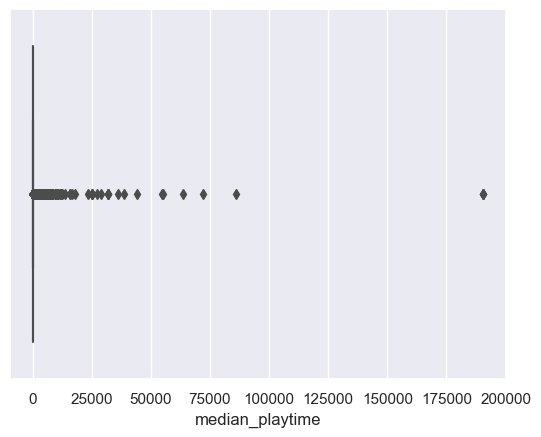

```python
sb.boxplot(data=a, x="median_playtime")
```

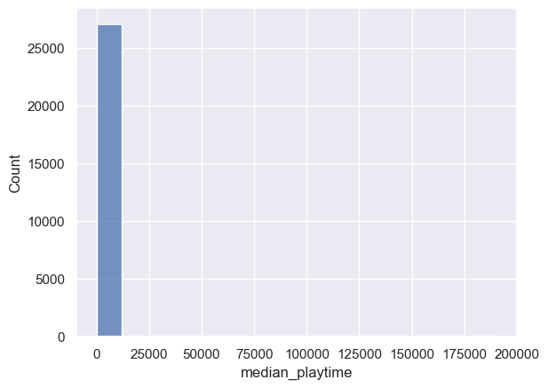

```python
sb.histplot(data=a,x="median_playtime")
```

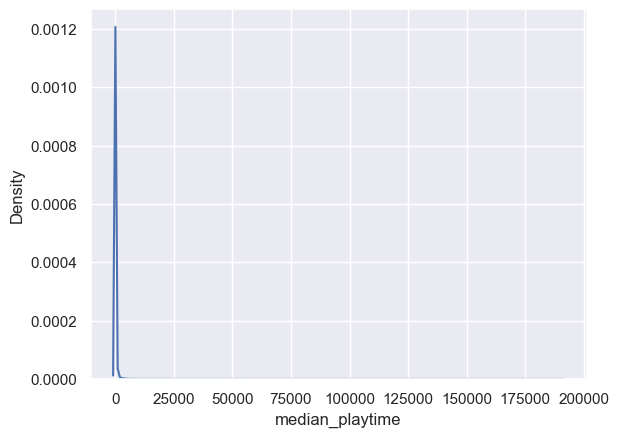

```python
sb.kdeplot(data=a,x="median_playtime")
```

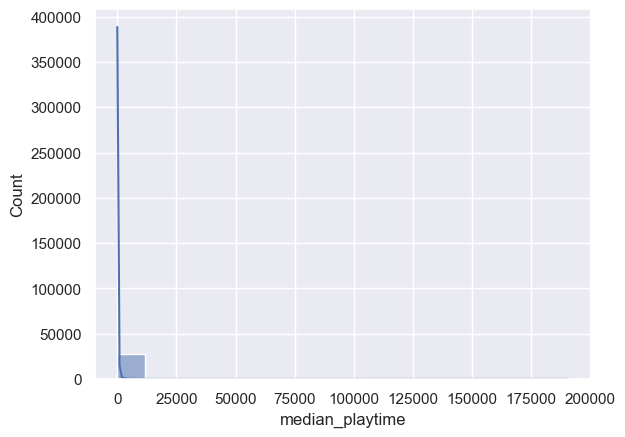

```python
sb.histplot(data=a,x="median_playtime", kde=True)
```

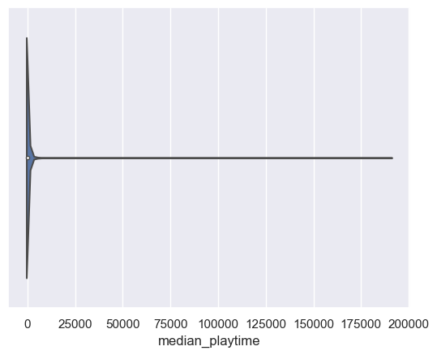

```python
sb.violinplot(data=a,x="median_playtime")
```